# Befolkningsframskrivning Västmanland 2026-2040 Magnus Forslund, analytiker

# Befolkningsframskrivning för mindre geografiska områden i Västmanland

## Bakgrund

Tillgång till befolkningsframskrivningar för mindre geografiska områden i Västmanlands kommuner saknas idag i hög utsträckning. Västerås stad gör återkommande en egen befolkningsframskrivning på nyckelkodområden (NYKO), som är den kommunala indelningen av kommunen i mindre geografiska enheter. I länets övriga kommuner görs framskrivningar framförallt på kommunnivå, ofta framtaget tillsammans med konsultföretag. Flera kommuner använder sig av Statistiska centralbyråns regionala framskrivning som tas fram för kommuner vart tredje år. NYKO ajourhålls och ägs av den enskilda kommunen och kan vara konstruerade på olika sätt, vilket gör att de sällan går att jämföra över kommungräns.

Behovet av en befolkningsframskrivning som dels går lägre än kommunal nivå och dels är möjlig att bryta ner för olika strategiska åldersgrupper bedöms som relativt stort i länet. Efterfrågan finns på såväl regional som kommunal nivå. En finare geografisk ansats har blivit alltmer nödvändig inom såväl strategisk planering som inom analys av mer avgränsade ämnesområden.

## Region Västmanlands framskrivning - en hybrid

Utgångspunkten i att ta fram en befolkningsframskrivning på låg geografisk nivå i Västmanland har varit att i så stor utsträckning som möjligt utgå ifrån Statistiska centralbyråns framskrivningar på kommunnivå, inklusive deras antaganden om framtida fruktsamhet och dödlighet. Som utgångspunkt har framskrivningen gjorts för DeSO, demografiska statistikområden. DeSO tas fram av SCB och är en rikstäckande indelning på låg regional nivå som kan aggregeras till Regionala statistikområden (RegSO), kommuner och län. DeSO delar in Sverige i drygt 6 000 områden där befolkningen i de flesta fall är mellan 700 och 3 000 personer per område. Indelningen tar hänsyn till geografiska förutsättningar så att gränserna i möjligaste mån följer exempelvis gator, vattendrag och järnvägar.

Snarare än att vara en helt ny, egen befolkningsframskrivning är detta alltså snarare en utveckling av SCB:s regionala framskrivning som möjliggör en nedbrytning på lägre geografiska nivåer samtidigt som den kan uppdateras årligen och därmed ta hänsyn till kortsiktiga förändringar på ett sätt som SCB:s version inte kan då den endast publiceras vart tredje år.

### Metodbeskrivning

DeSO är så pass stora områden att de får en relativt heterogen befolkning, de flesta område rymmer olika hustyper, upplåtelseformer och byggperioder, faktorer som vanligen påverkar åldersstrukturen i ett område. Eftersom områdena är så pass heterogena har vi gjort bedömningen att det bästa är att använda samma antaganden kring fruktsamhet och dödlighet för alla områden. Det är därmed främst den befintliga åldersstrukturen i området som påverkar hur många som föds respektive dör i framskrivningen. Däremot antas risken för någon av händelserna vara lika stor, oavsett vilket DeSO det är.

Utöver de naturliga befolkningsförändringarna (födda och döda) så påverkar effekten av flyttningar till och från ett område folkmängdens utveckling. I framskrivningen tittar vi inte på specifika flyttrisker, utan har använt en utglesningsmetod som utgår ifrån hur folkmängden har utvecklats mellan åren 2018-2025. Enkelt uttryckt kan man därmed säga att vi tar hänsyn till nettoeffekten, men inte de faktiska flyttningarna. Metoden har valts dels i brist på relevanta underlag och dels utifrån områdenas karaktär: eftersom de är så pass stora så kommer alla typer av flyttanledningar att finns med och därmed i någon mening urvattnas. I den absoluta merparten av länets DeSO så förekommer inte heller någon nyproduktion av bostäder, vilket annnars är en faktor som tydligt påverkan den lokala omflyttningen. Där nybyggnation av bostäder ändå sker i länet, främst i Västerås, så har vi en utökad metod för att hantera det. Det beskrivs mer utförligt i avsnittet Utökad metodbeskrivning.

Enkelt illustrerat så ser metoden ut på följande sätt. Vi har en startfolkmängd för år 2025 i varje område, fördelat efter kön och ålder. Varje person antas bli ett år äldre efterföljande år, vi applicerar dödsriskerna och de åldersspecifika fruksamhetstalen, vilket genererar nya 0-åringar varje år. Slutligen appliceras utglesningstalet vilket sammantaget ger den nya folkmängden efterföljande år. Sedan upprepas proceduren för varje prognosår, fram till år 2040.

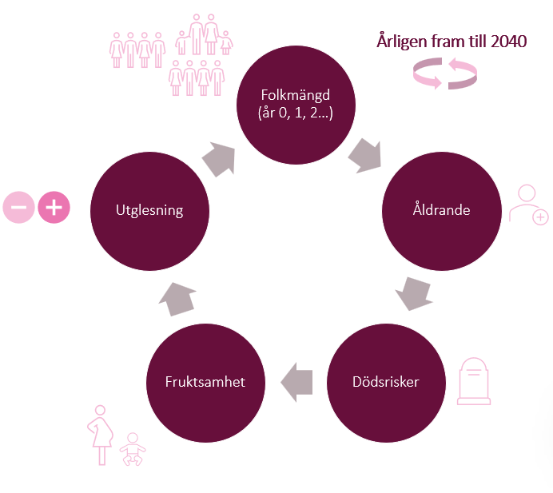

Framskrivningsmodellen: en hybrid av kohort- och utglesningsmetod

När vi har kört igenom modellen för alla prognosår får vi ett resultat som tydligt utgår ifrån den befintliga folkmängden och den historiska utvecklingen 2018-2025. Det kallas här den **okalibrerade versionen**. Eftersom vi villl kunna använda SCB:s framskrivning så görs därefter en avstämning (kalibrering) av den framskrivna folkmängden på kommunnivå mot SCB:s version. Vi vill helt enkelt att de båda versionerna ska stämma överens på kommunnivå för varje enskilt prognosår. Det innebär att folkmängden i den första, okalibrerade versionen kan behöva ökas eller minskas. Därefter görs steg två i kalibreringen, där folkmängden per DeSO, kön och åldersklass kalibreras för att stämma mot de nya kommunsummorna. Det ger oss en **kalibrerad version**, som överensstämmmer med SCB:s framskrivning på totalnivå men med möjlighet att bryta ner folkmängden efter DeSO, kön och ålder.

Som ett tredje steg tar vi även fram en **interpolerad version**. Enkelt uttryckt så ska den använda sig av den första, okalibrerade framskrivningen under de inledande prognosåren för att därefter gradvis anpassa sig till den kalibrerade framskrivningen. Det är främst ett svar på att SCB endast producerar sina framskrivningar vart tredje år, vilket innebär att om prognosen av olika anledningar hamnar snett i starten så kommer skevheten att bestå framåt. Den aktuella framskrivningen från SCB har år 2023 som senast kända folkmängd och många av de relativt snabba förändringar som inträffade 2024 och 2025 syns inte i framskrivningen. Det gäller såväl migrationens påverkan som de sjunkande födelsetalen. Av den anledningen tror vi helt enkelt att den okalibrerade versionen är den bästa under de inledande åren, men samtidigt att den inte har möjlighet att fånga upp troliga förändringar på längre sikt. Då är det istället bättre att återgå till SCB:s förväntade befolkningsutveckling i kommunerna.

Utifrån detta kan vi se de olika versionerna som tre olika scenarion:

- Interpolerad version = huvdalternativ (samlar det bästa från de två andra versionerna)
- Kalibrerad version (SCB) = högalternativ (har den mest positiva utvecklingen)
- Okalibrerad version = lågalternativ (fortsätter med de senaste åren utveckling)

## Resultat

Nedan visas utfallet av de två nya versionerna i relation till SCB:s kommunframskrivning (den kalibrerade versionen). I diagrammen syns den faktiska folkmängden för åren 2018 till och med 2025 tillsammans med de tre framskrivningarna. Det går att filtrera visningen efter någon av åldersklasserna samt efter kommun. På kommunnivå blir det ganska tydligt att den okalibrerade versionen ligger relativt nära SCB:s framskrivning för Västerås och att interpoleringen inte är särskilt omfattande. Både storleken på kommunen och det historiska tillväxtmönstret i Västerås påverkar detta.

Kommun

Åldersgrupp

[interactive chart not shown]

På samma sätt som ovan kan vi titta på de tre framskrivningarna på RegSO-nivå. I diagrammen nedan visas framskrivningarna för respektive RegSO efter åldersklass fördelat efter kommun.

[interactive chart not shown]

## Test av modellen

Även det inte finns något facit på vilken prognosversion som är “bäst” eller mest sannnolik så går det att testa modellen i viss utsträckning. Ett sätt är att köra modellen på ett antal tidigare år, där vi har faktisk folkmängd, för att kunna jämföra utfallet. Testet avsåg åren 2024 och 2025 och gav ett MAPE på 3,8% över de två åren.

MAPE är Mean Absolute Percentage Error, som visar genomsnittet av de absoluta procentuella avvikelserna mellan prognos och utfall.

Slutsatsen är att vi får en liten positiv bias, där modellen marginellt överskattar utvecklingen. Eftersom modellen arbetar på DeSO-nivå är det främst enskilda områden som drar upp variansen snarare än ett systematiskt genomgripande problem. Även storleken på respektive DeSO har betydelse, medelfelet blir betydligt större i de allra minsta områdena (färre än 500 invånare). Totalt sett har 153 av 171 DeSO i länet ett medelfel under 2,6 vilket är relativt starkt.

För det fortsatta arbetet med framskrivningsmodellen är tolkningen av testet att modellen klarar sig relativt bra. Det finns ingen systematisk bias som stör resultaten och den främsta svagheten gäller områden som exploateras. En annan del av testet visade också att det är bättre att basera utglesningstalet på en längre period, när vi testade färre år gav det ett större medelfel.

Det kvarstående problemet med exploateringsområden har hanterats genom att upprätta en lista över vilka DeSO som tillåts växa mer än det tak som annars är inbyggt i modellen. Efter kontakt med Västerås stad (där de större exploateringsområdena finns) har vi kunnat identifiera vilka DeSO det avser och jämfört våra respektive resultat i framskrivningarna. Det bedöms vara det bästa sättet att hantera den typen av avvikande områden. Den andra kategorin, områden med snabba förändringar utan byggnation, gör vi ingen extra anpassning för. Dels tror vi att åren 2023 och 2024 är unika sett till Skatteverkets insatser och att problemet därför kommer att vara mindre storlek framöver och även mildras när vi kan använda fler år i underlaget för utglesningen. Generellt sett kan inte heller den här typen av framskrivning fånga upp vändpunkter i utvecklingen, vilket ytterligare stärker behovet av den interpolerade versionen som på sikt ansluter till SCB:s förväntade utveckling.

## Utökad metodbeskrivning

Modellen använder underlagsdata som hämtats ifrån SCB:s Regiondatabas STATIV och i övrigt uppgifter ifrån SCB:s publika databas SSD.

### Underlag för Västmanland

- Åldersstruktur: folkmängd 2018-2025 efter kön och ettårsklasser per DeSO
- Tidsserie: folkmängd totalt per DeSO 2018-2025
- Nyckel: Kommun/DeSO/RegSO

Vi har utgått ifrån den senaste DeSO-indelningen från 2025 för samtliga år i underlaget, då detta är möjligt att göra i STATIV-databasen även för åren innan den nya indelningen infördes. Underlaget med nyckel mellan olika nivåer används för att kunna aggregera upp framskrivningen på olika geografiska nivåer. Den primära redovisningsnivån är RegSO-nivå, främst för att områdena är namnsatta, vilket underlättar kommunikationen och förståelsen kring resultaten. Redovisningen sker främst i de angivna åldersklasserna 0-17 år, 18-44 år, 45-64 år, 65-84 år och 85+ år men även andra indelningar skulle vara möjligt att göra. Grupperna bör dock inte vara alltför små, då det ganska snabbt ökar osäkerheten.

### Underlag för riket

- Fruktsamhetstal för kvinnor i ettårsklasser 15-49 år (2026-2050)
- Dödsrisker för kvinnor och män i ettårsklasser (2026-2050)
- SCB kommunprognos: folkmängd efter kön och ettårsklasser per kommun (2024-2050)

Tabellerna är de senast tillgängliga från SCB:s riksantaganden och vi applicerar dessa på de egna befolkningsunderlagen. Kommunprognosen är den senast tillgängliga på kommunnivå. Senast kända folkmängd i den här version är år 2023.

### Utglesningstal för att hantera flyttningar

Flyttningar är svåra att hantera i en framskrivning på delområden som DeSO. Eftersom DeSO är så pass stora sett till folkmängd och typ av bebyggelse går det inte att hantera dem efter specifik karaktäristika, då de flesta typer av bostäder och åldersstrukturer finns representerade inom ett DeSO. Därför har vi valt att använda utglesningsmetoden för framskrivningen i kombination med de tidigare beskrivna antagandena för fruktsamhet och dödlighet. Utglesningstalet motsvarar en årlig genomsnittlig tillväxt per DeSO baserad på utvecklingen 2018-2025. I en modell av det här slaget kan vissa områden sticka iväg orimligt mycket, därför har vi applicerat ett generellt tillväxttak och motsvarande golv för de årliga förändringarna. Var taket och golv sätts behöver tänkas igenom vid varje tillfälle modellen används. I nuläget när få kommuner har en befolkningsökning i hela landet har vi satt gränsen vid 1% tillväxt och -2% minskning. Här görs dock undantag för ett antal utpekade DeSO, där det finns kännedom om att det finns en hög grad av exploatering och nybyggnation. Det gäller särskilt i områden som tidigare varit små befolkningsmässigt och därefter vuxit kraftigt. I den aktuella framskrivningen tillåts i sådana områden upp till 5% tillväxt.

### Kalibrering mot SCB:s framskrivning

Kalibreringen görs i två omgångar. I steg 1 kalibreras DeSO-framskrivningens befolkning mot SCB:s kommunprognos efter kön och ålder. Därefter, i steg 2, kalibreras ålder och kön i respektive DeSO mot den nya kommuntotalen. Således: den kalibrerade prognosen är konstruerad så att kommuntotalen och åldersfördelningen per kommun överensstämmer med SCB:s kommunprognos, medan den rumsliga fördelningen mellan DeSO:n inom varje kommun bygger på den egna modellens skattningar.

Slutligen bör det också nämnas att det för den äldsta åldersgruppen kan uppstå en mindre skevhet till följd av att SCB:s framskrivning på ettårsklasser slår ihop alla personer äldre än 100 år, medan vi har faktisk ålder även för dessa i de egna underlagen. Den kan skapa några avvikelser, fgramförallt i mindre kommuner, men torde inte påverka tillförlitligheten i framskrivningen som helhet då det rör sig om väldigt få individer.